# Case Study: How Does a Bike-Share Navigate Speedy Success?

Capstone Project for Google Data Analytics Professional Certificate

Elliott Styles

11/4/2021

## Cyclistic Ridership Analysis

### Scenario and Business Task

#### Hello!

As part of the Google Data Analytics Professional Certificate, both to display developed skills and to begin building a portfolio, students are encouraged to create a case study capstone project. This is that project. Here goes!

In this scenario, Cyclistic, a fictional bike share company based in Chicago, is looking increase revenue by analyzing their ridership data. The team at Cyclistic have determined that annual members are more profitable than casual users, and would like to develop a marketing strategy to encourage casual users to sign up for annual memberships. I have been tasked with finding the use habits of casual users and annual members and suggesting some strategies for gaining more annual members.

The data for Cyclistic is based on ridership data for Divvy (available under [this licence](https://www.divvybikes.com/data-license-agreement)). For this analysis, I used the data from the last year (October 2020 - September 2021) and downloaded it from [this link](https://divvy-tripdata.s3.amazonaws.com/index.html).

My analysis and visualizations were performed and created in RStudio.

### R Data Manipulation and Visualization Preperation

#### Setting up my environment

Setting up my R environment by loading ‘tidyverse’, ‘lubridate’, ‘ggplot2’, ‘ggpubr’, and ‘scales’.

```r
# loading necessary packages
library(tidyverse)
library(lubridate)
library(ggplot2)
library(ggpubr)
library(scales)
```

#### Importing the data set

Downloading the data from Divvy and importing each csv into it’s own data frame.

```r
# import Divvy sheets into data frames
oct_2020 <- read_csv("202010-divvy-tripdata.csv")
nov_2020 <- read_csv("202011-divvy-tripdata.csv")
dec_2020 <- read_csv("202012-divvy-tripdata.csv")
jan_2021 <- read_csv("202101-divvy-tripdata.csv")
feb_2021 <- read_csv("202102-divvy-tripdata.csv")
mar_2021 <- read_csv("202103-divvy-tripdata.csv")
apr_2021 <- read_csv("202104-divvy-tripdata.csv")
may_2021 <- read_csv("202105-divvy-tripdata.csv")
jun_2021 <- read_csv("202106-divvy-tripdata.csv")
jul_2021 <- read_csv("202107-divvy-tripdata.csv")
aug_2021 <- read_csv("202108-divvy-tripdata.csv")
sep_2021 <- read_csv("202109-divvy-tripdata.csv")
```

#### Cleaning, Aggregating, and Transforming the Data

Adjusting the data type for oct_2020 and nov_2020 to match those of the more recent files.

```r
# convert start_station_id and end_station_id data types to character to match most recent data
oct_2020 <- mutate(oct_2020, start_station_id = as.character(start_station_id))
oct_2020 <- mutate(oct_2020, end_station_id = as.character(end_station_id))
nov_2020 <- mutate(nov_2020, start_station_id = as.character(start_station_id))
nov_2020 <- mutate(nov_2020, end_station_id = as.character(end_station_id))
```

Compiling monthly data in to one data frame.

```r
# make one big data frame (all_trips)
all_trips <- bind_rows(oct_2020,
                       nov_2020,
                       dec_2020,
                       jan_2021,
                       feb_2021,
                       mar_2021,
                       apr_2021,
                       may_2021,
                       jun_2021,
                       jul_2021,
                       aug_2021,
                       sep_2021)
```

Adding new columns to the new data frame for additional analysis and summary data, as well as visualization structuring and contextualization (ten_minute_mark, day_of_week).

```r
# add new columns for date, month, day, year, day_of_week, start_time, ten_minute_mark, and ride_length
# for new aggregation options and calculated data
all_trips$date <- as.Date(all_trips$started_at)
all_trips$month <- month(all_trips$date, label=TRUE)
all_trips$day <- format(as.Date(all_trips$date), "%d")
all_trips$year <-format(as.Date(all_trips$date), "%Y")
all_trips$day_of_week <- format(as.Date(all_trips$date), "%A")
all_trips$start_time <- format(all_trips$started_at, "%H:%M:%S")
all_trips$ride_length <- difftime(all_trips$ended_at, all_trips$started_at)
# group daily trips into 10 minute bins
all_trips$ten_minute_mark <- (as.numeric(format(all_trips$started_at, "%H"))*60 + as.numeric(format(all_trips$started_at, "%M"))) %/% 10
# set days of the week order
all_trips$day_of_week <- ordered(all_trips$day_of_week, levels=c("Sunday", "Monday", "Tuesday", "Wednesday", "Thursday", "Friday", "Saturday"))
```

Data points containing NA or negative values or flagged as non user check outs (company testing) are removed from the data set and not used for analysis.

```r
# remove unused or irrelevant data- quality checks (HQ QR, WATSON TESTING), NA values, and negative ride lengths
all_trips_v2 <- all_trips[!(all_trips$start_station_name == "HQ QR" |
                            all_trips$start_station_name == "WATSON TESTING - DIVVY" |
                            all_trips$ride_length<0),]
all_trips_v2 <- all_trips_v2 %>% drop_na()
```

### Analysis and Visualizations

#### Expectations

My initial expectations were to see distinctions between the two member types, in terms of when they were most active, both on a day to day basis, and month to month. I also expected that there might be some differences in bike type preference, under the assumption that casual one-time users might be more inclined to try out different types of annual members, who I expect would be using the bikes for commuting and other regular travel might be more inclined to stick to the basics. Finally, I wanted to see if there were any regional hot spots, expecting that tourist areas might be popular for casual purchases, and stations in residential areas might have more use by annual members.

#### Analysis

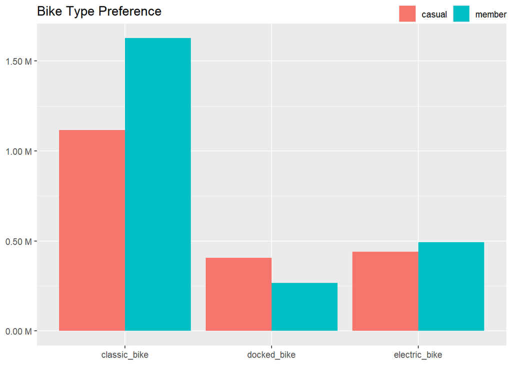

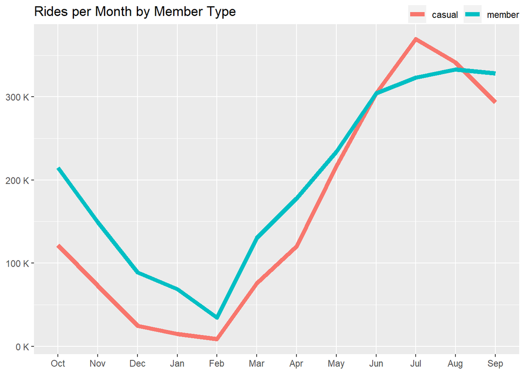

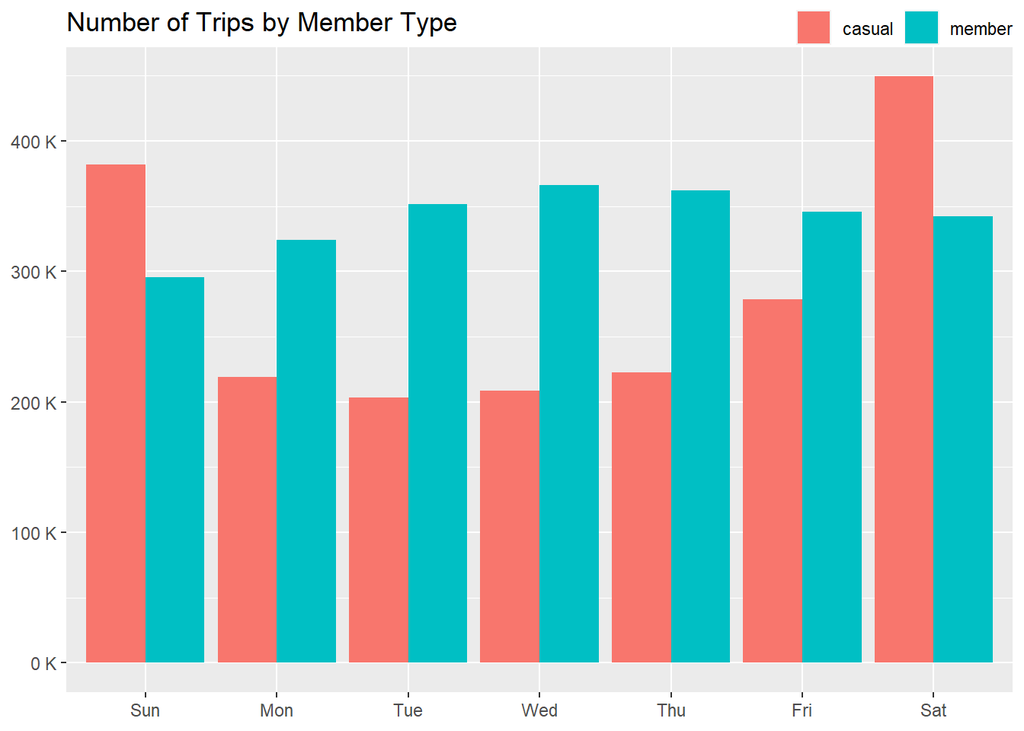

Interestingly, another distinct trend in weekday analysis, is that the average trip duration is significantly higher for casual riders consistently across all days. The daily trip length average for casual users is more than double that of annual members. This could be that annual members are using the bikes for regular travel, and don’t spend any time with the bike that isn’t used for getting from point A to point B, where casual users maybe spending more time using their bikes to get around and explore, and then continuing to use them even once they’ve arrived at their destination.

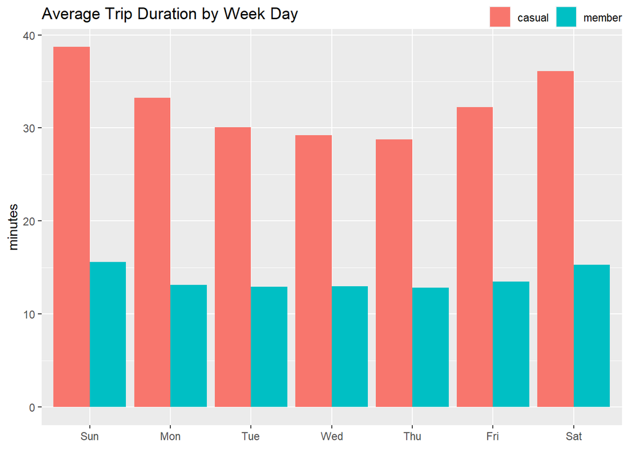

By charting the number of trips across the day (grouped into 10 minute increments) we are able to see that while both user types have a spike in usage around 5pm, aligning with the end of the work day, it appears that only annual members tend to make use of bikes for the morning commute (7am - 9am). Most usage by casual users occurs after 12pm, with a spike at 5pm.

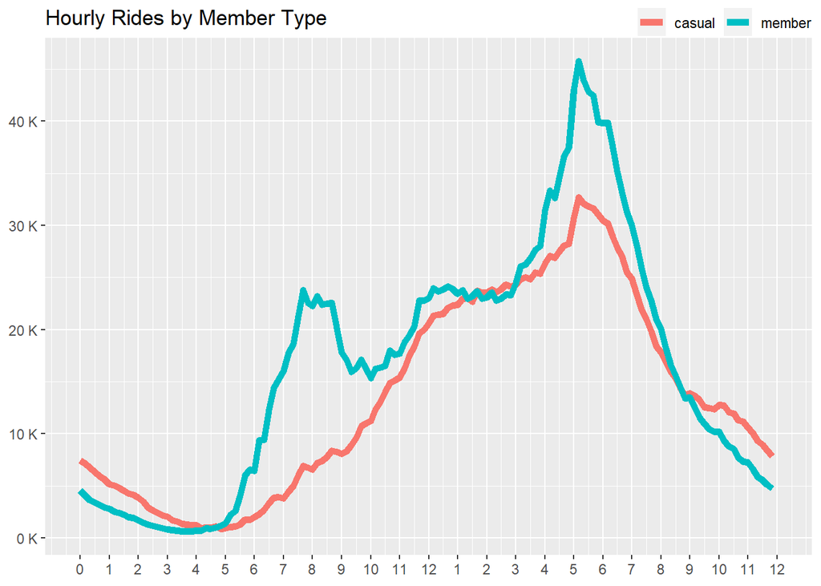

Finally, in terms of making specific decisions for marketing purposes, it would be useful to know which stations are most frequented by casual users. This list of the most used stations by each user type confirms my expectation that high usage by casual users could be in tourist locations, here specifically showing Millennium Park, Shedd Aquarium, and Theater on the Lake. Crucially, Streeter Dr & Grand Ave has significantly more usage by casual users than any other station by either user type. It is also worth noting that both Theater on the Lake and Wells St & Concord Ln both appear on both lists. This could be useful if wanting to show casual users who use those stations what annual members are getting out of their memberships.

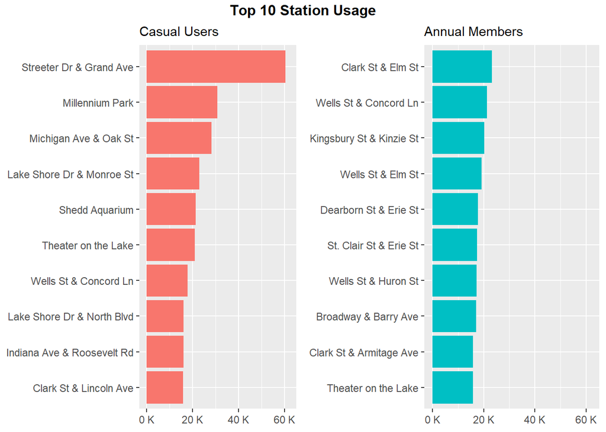

#### Summary

The most definitive differences, distinguishing casual users, come in the form of:

- Increased weekend usage
- Significantly longer trip length (more than double)
- Primarily afternoon and evening usage
- Hot spots in tourist locations, specifically Streeter Dr & Grand Ave

### Conclusion

Based on the data from the previous year of Cyclistic’s ridership, we can make some distinct decisions to guide the upcoming marketing strategy for converting casual users to annual members.

1: Casual users ride almost twice as much on weekends vs weekdays.

- Add a new type of weekend pass, available to members, giving access to bikes through both days of the weekend, at a cheaper price point that purchasing 2 day passes.
- Give members a discounted prices of weekend rides, encouraging weekend riders to become members, and encouraging those new members to use bikes throughout the week as well.

2: Casual users trip length is more than double that of annual members.

- Give members access to weekend day passes that are not paid per hour, allowing casual users who become members to take longer trips for cheaper than buying bike time by the hour.

3: Casual user trips are primarily in the afternoon and after 5pm.

- The primary take away here is that marketing should not target morning riders, as these are already annual members.

4: Casual users make use of bikes in tourist areas more frequently than annual members.

- Develop a tourist pass program, with promotions associated with the stations near tourist locations. Give annual members special and exclusive access to a particular subset of bikes, allowing them to guarantee access without worrying about the station running out.